# ggcoefstats

Indrajeet Patil

2022-01-15

You can cite this package/vignette as:

```
  Patil, I. (2021). Visualizations with statistical details: The
  'ggstatsplot' approach. Journal of Open Source Software, 6(61), 3167,
  doi:10.21105/joss.03167

A BibTeX entry for LaTeX users is

  @Article{,
    doi = {10.21105/joss.03167},
    url = {https://doi.org/10.21105/joss.03167},
    year = {2021},
    publisher = {{The Open Journal}},
    volume = {6},
    number = {61},
    pages = {3167},
    author = {Indrajeet Patil},
    title = {{Visualizations with statistical details: The {'ggstatsplot'} approach}},
    journal = {{Journal of Open Source Software}},
  }
```

Lifecycle:

[figure not shown]

The function `ggcoefstats` generates **dot-and-whisker plots** for regression models saved in a tidy data frame. The tidy dataframes are prepared using `parameters::model_parameters`. Additionally, if available, the model summary indices are also extracted from `performance::model_performance`.

In this vignette, we will see examples of how to use this function. We will try to cover as many classes of objects as possible. Unfortunately, there is no single dataset that will be helpful for carrying out all types of regression analyses and, therefore, we will use various datasets to explore data-specific hypotheses using regression models.

# General structure of the plots

Although the statistical models displayed in the plot may differ based on the class of models being investigated, there are few aspects of the plot that will be invariant across models:

- The dot-whisker plot contains a dot representing the **estimate** and their **confidence intervals** (`95%` is the default). The estimate can either be effect sizes (for tests that depend on the `F`-statistic) or regression coefficients (for tests with `t`-, $\chi^{2}$-, and `z`-statistic), etc. The confidence intervals can sometimes be asymmetric if bootstrapping was used.
- The label attached to dot will provide more details from the statistical test carried out and it will typically contain estimate, statistic, and *p*-value.
- The caption will contain diagnostic information, if available, about models that can be useful for model selection: The smaller the Akaike’s Information Criterion (**AIC**) and the Bayesian Information Criterion (**BIC**) values, the “better” the model is.
- The output of this function will be a `{ggplot2}` object and, thus, it can be further modified (e.g., change themes, etc.) with `{ggplot2}` functions.

# Supported models

Most of the regression models that are supported in the underlying packages are also supported by `ggcoefstats`.

```r
insight::supported_models()
```

```
#>   [1] "aareg"             "afex_aov"          "AKP"
#>   [4] "Anova.mlm"         "aov"               "aovlist"
#>   [7] "Arima"             "averaging"         "bamlss"
#>  [10] "bamlss.frame"      "bayesQR"           "bayesx"
#>  [13] "BBmm"              "BBreg"             "bcplm"
#>  [16] "betamfx"           "betaor"            "betareg"
#>  [19] "BFBayesFactor"     "bfsl"              "BGGM"
#>  [22] "bife"              "bifeAPEs"          "bigglm"
#>  [25] "biglm"             "blavaan"           "blrm"
#>  [28] "bracl"             "brglm"             "brmsfit"
#>  [31] "brmultinom"        "btergm"            "censReg"
#>  [34] "cgam"              "cgamm"             "cglm"
#>  [37] "clm"               "clm2"              "clmm"
#>  [40] "clmm2"             "clogit"            "coeftest"
#>  [43] "complmrob"         "confusionMatrix"   "coxme"
```

[output cut: 54 more lines]

# Summary of graphics

| graphical element | `geom_` used | argument for further modification |
| --- | --- | --- |
| regression estimate | `ggplot2::geom_point` | `point.args` |
| error bars | `ggplot2::geom_errorbarh` | `errorbar.args` |
| vertical line | `ggplot2::geom_vline` | `vline.args` |
| label with statistical details | `ggrepel::geom_label_repel` | `stats.label.args` |

# Summary of meta-analysis tests

**Hypothesis testing** and **Effect size estimation**

| Type | Test | Effect size | CI? | Function used |
| --- | --- | --- | --- | --- |
| Parametric | Meta-analysis via random-effects models | $\beta$ | ✅ | `metafor::metafor` |
| Robust | Meta-analysis via robust random-effects models | $\beta$ | ✅ | `metaplus::metaplus` |
| Bayes | Meta-analysis via Bayesian random-effects models | $\beta$ | ✅ | `metaBMA::meta_random` |

# Examples of supported models

First let’s load the needed library.

```r
library(ggstatsplot)
```

The following demos are in **no particular order**.

## linear mixed-effects model (`lmer`/`lmerMod`)

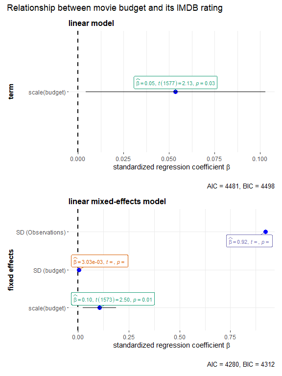

```r
# set up
library(lme4)
library(ggstatsplot)
set.seed(123)

# lm model
mod1 <- stats::lm(formula = scale(rating) ~ scale(budget), data = movies_long)

# merMod model
mod2 <- lme4::lmer(
  formula = scale(rating) ~ scale(budget) + (budget | genre),
  data = movies_long,
  control = lme4::lmerControl(calc.derivs = FALSE)
)

# combining the two different plots
combine_plots(
  plotlist = list(
    # model 1: simple linear model
    ggcoefstats(
      x = mod1,
      title = "linear model",
      exclude.intercept = TRUE # hide the intercept
    ) +
      ggplot2::labs(x = parse(text = "'standardized regression coefficient' ~italic(beta)")),
    # model 2: linear mixed-effects model
    ggcoefstats(
      x = mod2,
      title = "linear mixed-effects model",
      exclude.intercept = TRUE # hide the intercept
    ) +
      ggplot2::labs(
        x = parse(text = "'standardized regression coefficient' ~italic(beta)"),
        y = "fixed effects"
      )
  ),
  plotgrid.args = list(nrow = 2),
  annotation.args = list(title = "Relationship between movie budget and its IMDB rating")
)
```

```r
# setup
set.seed(123)
library(lme4)
library(parameters)

# tidy output
parameters::model_parameters(
  lme4::lmer(
    formula = scale(rating) ~ scale(budget) + (budget | genre),
    data = movies_long,
    control = lme4::lmerControl(calc.derivs = FALSE)
  )
)
```

```
#> # Fixed Effects
#>
#> Parameter   | Coefficient |   SE |        95% CI | t(1573) |     p
#> ------------------------------------------------------------------
#> (Intercept) |       -0.06 | 0.14 | [-0.33, 0.20] |   -0.46 | 0.649
#> budget      |        0.10 | 0.04 | [ 0.02, 0.19] |    2.50 | 0.013
#>
#> # Random Effects
#>
#> Parameter                     | Coefficient
#> -------------------------------------------
#> SD (Intercept: genre)         |        0.43
#> SD (budget: genre)            |    3.03e-03
#> Cor (Intercept~budget: genre) |       -0.49
#> SD (Residual)                 |        0.92
```

## summary grid from `emmeans` package (`emmGrid`)

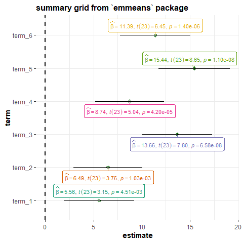

```r
# setup
set.seed(123)
library(emmeans)

# linear model for sales of oranges per day
oranges_lm1 <-
  stats::lm(
    formula = sales1 ~ price1 + price2 + day + store,
    data = oranges
  )

# reference grid; see vignette("basics", package="emmeans")
oranges_rg1 <- emmeans::ref_grid(oranges_lm1)
marginal <- emmeans::emmeans(oranges_rg1, "day")

# plot
ggcoefstats(
  x = marginal,
  point.args = list(color = "darkgreen", shape = 9),
  title = "summary grid from `emmeans` package"
)
```

Another example with output containing effect sizes

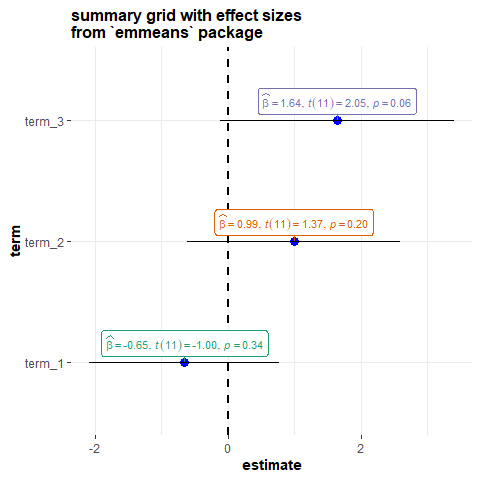

```r
# setup
set.seed(123)
library(emmeans)

# model and effect sizes
fiber.lm <- lm(strength ~ diameter + machine, data = fiber)
emm <- emmeans::emmeans(fiber.lm, "machine")
es <- emmeans::eff_size(emm, sigma = sigma(fiber.lm), edf = df.residual(fiber.lm))

# plot
ggcoefstats(
  x = es,
  title = "summary grid with effect sizes\nfrom `emmeans` package"
)
```

## Bayesian additive models for location scale and shape (`bamlss`)

```r
# setup
set.seed(123)
library(bamlss)
data("SwissLabor", package = "AER")

# formula
f <- participation ~ income + age + education + youngkids + oldkids + foreign + I(age^2)

# model
b_bamlss <-
  bamlss::bamlss(
    formula = f,
    family = "binomial",
    data = SwissLabor
  )
```

[output not shown]

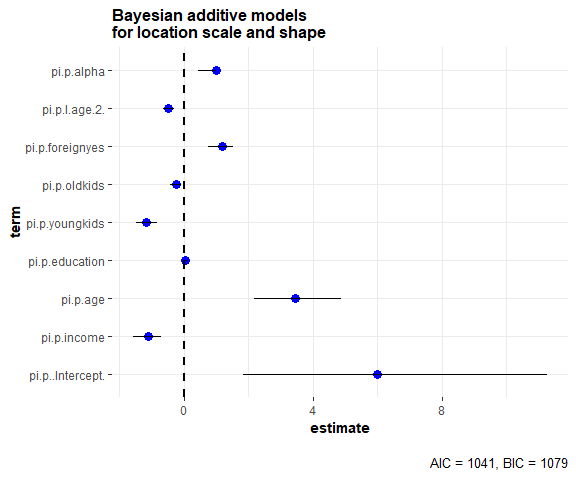

```r
# plot
ggcoefstats(
  x = b_bamlss,
  title = "Bayesian additive models \nfor location scale and shape"
)
```

## Bayes Factor (`BFBayesFactor`)

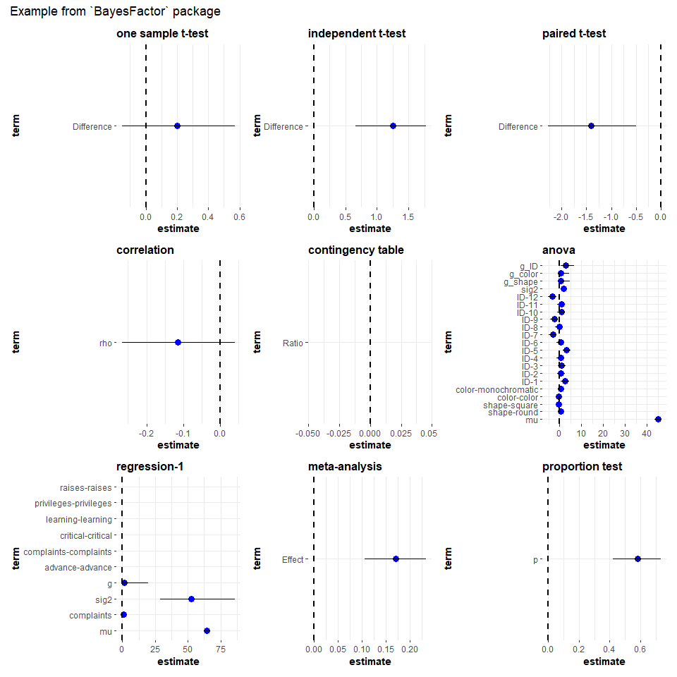

```r
# setup
set.seed(123)
library(BayesFactor)
library(ggstatsplot)

# one sample t-test
mod1 <- ttestBF(mtcars$wt, mu = 3)

# independent t-test
mod2 <- ttestBF(formula = wt ~ am, data = mtcars)

# paired t-test
mod3 <- ttestBF(x = sleep$extra[1:10], y = sleep$extra[11:20], paired = TRUE)

# correlation
mod4 <- correlationBF(y = iris$Sepal.Length, x = iris$Sepal.Width)

# contingency tabs (not supported)
data("raceDolls")
mod5 <- contingencyTableBF(
  raceDolls,
  sampleType = "indepMulti",
  fixedMargin = "cols"
)

# anova
data("puzzles")
mod6 <- anovaBF(
  formula = RT ~ shape * color + ID,
  data = puzzles,
  whichRandom = "ID",
  whichModels = "top",
  progress = FALSE
)

# regression-1
mod7 <- regressionBF(rating ~ ., data = attitude, progress = FALSE)

# meta-analysis
t <- c(-.15, 2.39, 2.42, 2.43, -.15, 2.39, 2.42, 2.43)
N <- c(100, 150, 97, 99, 99, 97, 100, 150)
mod8 <- meta.ttestBF(t, N, rscale = 1, nullInterval = c(0, Inf))

# proportion test
mod9 <- proportionBF(y = 15, N = 25, p = .5)

# list of plots
combine_plots(
  plotlist = list(
    ggcoefstats(mod1, title = "one sample t-test"),
    ggcoefstats(mod2, title = "independent t-test"),
    ggcoefstats(mod3, title = "paired t-test"),
    ggcoefstats(mod4, title = "correlation"),
    ggcoefstats(mod5, title = "contingency table"),
    ggcoefstats(mod6, title = "anova"),
    ggcoefstats(mod7, title = "regression-1"),
    ggcoefstats(mod8, title = "meta-analysis"),
    ggcoefstats(mod9, title = "proportion test")
  ),
  annotation.args = list(title = "Example from `BayesFactor` package")
)
```

## Fixed Effects Individual Slope Estimator (`feis`)

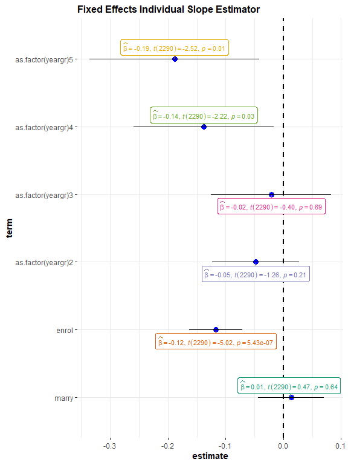

```r
# setup
set.seed(123)
library(feisr)
data("mwp", package = "feisr")

# model
feis.mod <-
  feisr::feis(
    formula = lnw ~ marry + enrol + as.factor(yeargr) | exp + I(exp^2),
    data = mwp,
    id = "id",
    robust = TRUE
  )

# plot
ggcoefstats(
  x = feis.mod,
  title = "Fixed Effects Individual Slope Estimator"
)
```

## omnibus ANOVA (`aov`)

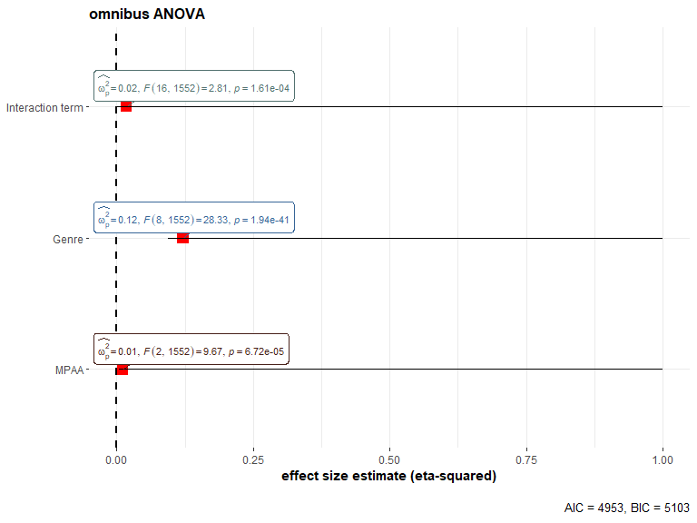

```r
# setup
set.seed(123)
library(ggstatsplot)
library(ggplot2)

# model
mod_aov <- stats::aov(formula = rating ~ mpaa * genre, data = movies_long)

# plot
ggcoefstats(
  x = mod_aov,
  effsize = "omega", # changing the effect size estimate being displayed
  point.args = list(color = "red", size = 4, shape = 15), # changing the point geom
  package = "dutchmasters", # package from which color palette is to be taken
  palette = "milkmaid", # color palette for labels
  title = "omnibus ANOVA", # title for the plot
  exclude.intercept = TRUE
) +
  # further modification with the ggplot2 commands
  # note the order in which the labels are entered
  ggplot2::scale_y_discrete(labels = c("MPAA", "Genre", "Interaction term")) +
  ggplot2::labs(x = "effect size estimate (eta-squared)", y = NULL)
```

Note that we can also use this function for model selection. You can try out different models with the code below and see how the AIC and BIC values change.

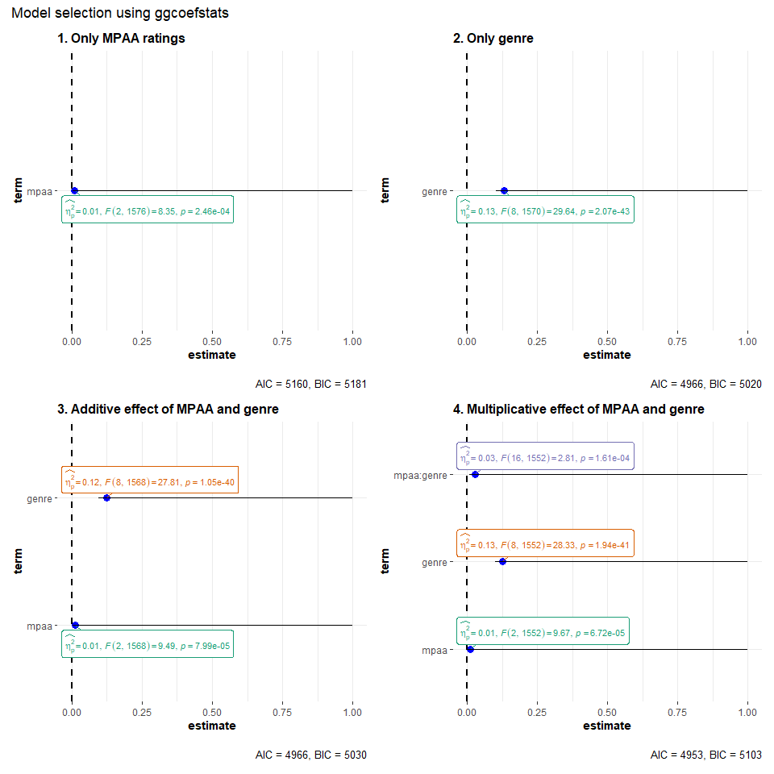

```r
# setup
set.seed(123)
library(ggstatsplot)

# plot
combine_plots(
  plotlist = list(
    # model 1
    ggcoefstats(
      x = stats::aov(formula = rating ~ mpaa, data = movies_long),
      title = "1. Only MPAA ratings"
    ),
    # model 2
    ggcoefstats(
      x = stats::aov(formula = rating ~ genre, data = movies_long),
      title = "2. Only genre"
    ),
    # model 3
    ggcoefstats(
      x = stats::aov(formula = rating ~ mpaa + genre, data = movies_long),
      title = "3. Additive effect of MPAA and genre"
    ),
    # model 4
    ggcoefstats(
      x = stats::aov(formula = rating ~ mpaa * genre, data = movies_long),
      title = "4. Multiplicative effect of MPAA and genre"
    )
  ),
  annotation.args = list(title = "Model selection using ggcoefstats")
)
```

## conditional logit models (`mclogit`)

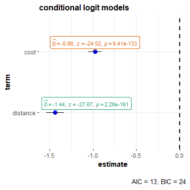

```r
# setup
set.seed(123)
library(mclogit)
data(Transport)

# model
mod_mclogit <-
  mclogit::mclogit(
    formula = cbind(resp, suburb) ~ distance + cost,
    data = Transport,
    control = mclogit::mclogit.control(trace = FALSE)
  )

# plot
ggcoefstats(
  x = mod_mclogit,
  title = "conditional logit models"
)
```

## mixed conditional logit models (`mmclogit`)

```r
# setup
set.seed(123)
library(mclogit)
data(electors)

# model
mod_mclogit <-
  mclogit::mclogit(
    formula = cbind(Freq, interaction(time, class)) ~
    econ.left / class + welfare / class + auth / class,
    random = ~ 1 | party.time,
    data = within(electors, party.time <- interaction(party, time))
  )
```

[output not shown]

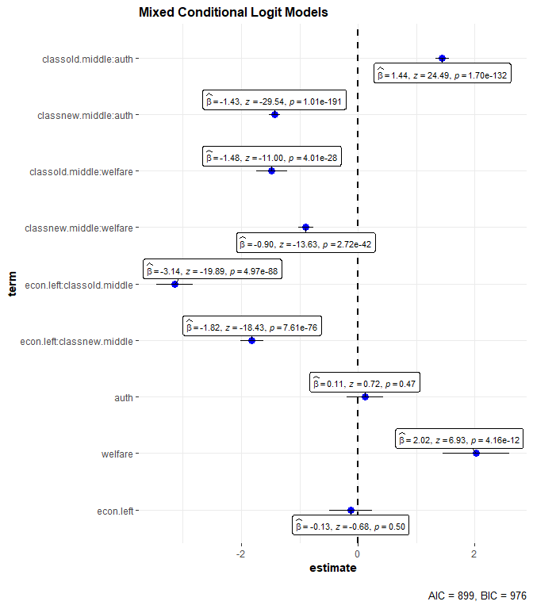

```r
# plot
ggcoefstats(
  x = mod_mclogit,
  title = "Mixed Conditional Logit Models"
)
```

## anova with `car` package (`Anova`)

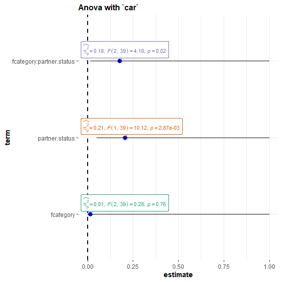

```r
# setup
set.seed(123)
library(car)
library(ggstatsplot)

# model
mod_Anova <-
  car::Anova(stats::lm(
    formula = conformity ~ fcategory * partner.status,
    data = Moore,
    contrasts = list(fcategory = contr.sum, partner.status = contr.sum)
  ))

# plot
ggcoefstats(
  x = mod_Anova,
  title = "Anova with `car`"
)
```

## ANOVA with `car` package on multiple linear models (`Anova.mlm`)

```r
# setup
set.seed(123)
library(car)

# data
dv <- c(1, 3, 4, 2, 2, 3, 2, 5, 6, 3, 4, 4, 3, 5, 6)
subject <- factor(c(
  "s1", "s1", "s1", "s2", "s2", "s2", "s3", "s3", "s3",
  "s4", "s4", "s4", "s5", "s5", "s5"
))
myfactor <- factor(c(
  "f1", "f2", "f3", "f1", "f2", "f3", "f1", "f2", "f3",
  "f1", "f2", "f3", "f1", "f2", "f3"
))
mydata <- data.frame(dv, subject, myfactor)

dvm <- with(mydata, cbind(
  dv[myfactor == "f1"],
  dv[myfactor == "f2"], dv[myfactor == "f3"]
))

# model
mlm1 <- lm(dvm ~ 1)

rfactor <- factor(c("f1", "f2", "f3"))

# model
mlm1.aov <-
  car::Anova(mlm1,
    idata = data.frame(rfactor),
    idesign = ~rfactor,
    type = "III"
  )

# plot
ggcoefstats(
  x = mlm1.aov,
  title = "ANOVA with `car` on multiple linear models"
)
```

[output not shown]

## Anova with `ez` package

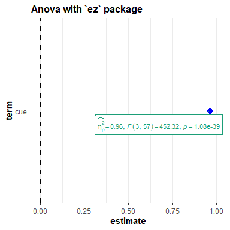

```r
set.seed(123)
library(ez)
data(ANT)

# run an ANOVA on the mean correct RT data.
rt_anova <-
  suppressWarnings(ez::ezANOVA(
    data = ANT[ANT$error == 0, ],
    dv = rt,
    wid = subnum,
    within = cue,
    detailed = TRUE,
    return_aov = TRUE
  ))

# plot
ggcoefstats(
  x = rt_anova$aov,
  title = "Anova with `ez` package"
)
```

## linear model (`lm`)

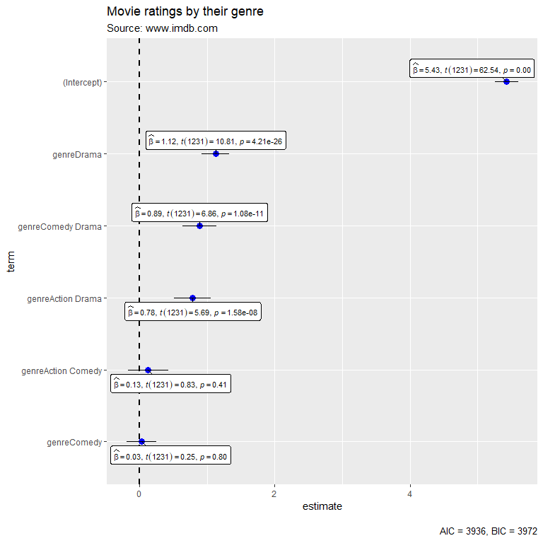

```r
# setup
set.seed(123)

# data
df <- dplyr::filter(
  movies_long,
  genre %in% c(
    "Action",
    "Action Comedy",
    "Action Drama",
    "Comedy",
    "Drama",
    "Comedy Drama"
  )
)

# plot
ggcoefstats(
  x = stats::lm(formula = rating ~ genre, data = df),
  sort = "ascending", # sorting the terms of the model based on estimate values
  ggtheme = ggplot2::theme_gray(), # changing the default theme
  stats.label.color = c("#CC79A7", "darkgreen", "#0072B2", "darkred", "black", "red"),
  title = "Movie ratings by their genre",
  subtitle = "Source: www.imdb.com"
)
```

The same output will also be returned for objects of type `summary.lm`.

## standardized regression coefficients with `lm` (`lm.beta`)

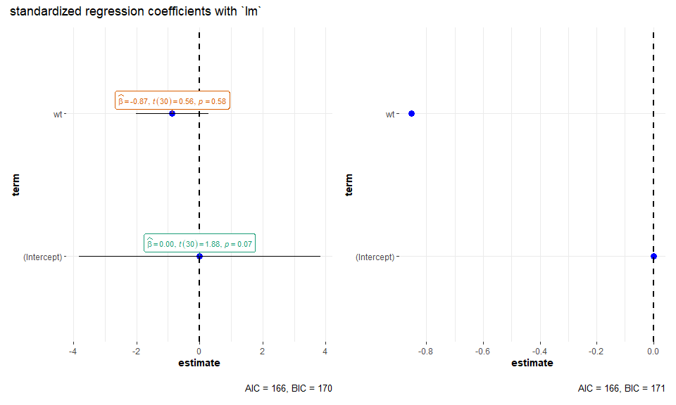

```r
# setup
set.seed(123)
library(MASS)
library(lm.beta)

# model
mod.lm <- stats::lm(formula = mpg ~ wt, data = mtcars)
mod.robust <- MASS::rlm(formula = mpg ~ wt, data = mtcars)
mod.beta <- lm.beta::lm.beta(mod.lm)
mod.robust.beta <- lm.beta::lm.beta(mod.robust)

# plot
combine_plots(
  plotlist = list(
    ggcoefstats(mod.beta),
    ggcoefstats(mod.robust.beta, stats.labels = FALSE)
  ),
  annotation.args = list(title = "standardized regression coefficients with `lm`")
)
```

## bounded memory linear regression (`biglm`)

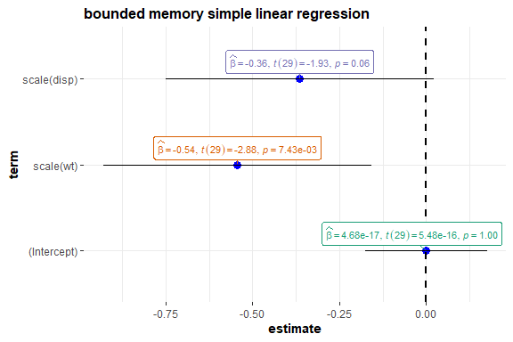

```r
# setup
set.seed(123)
library(biglm)

# model
bfit1 <-
  biglm(
    formula = scale(mpg) ~ scale(wt) + scale(disp),
    data = mtcars
  )

# plot
ggcoefstats(
  x = bfit1,
  title = "bounded memory simple linear regression"
)
```

## bounded memory general linear regression (`bigglm`)

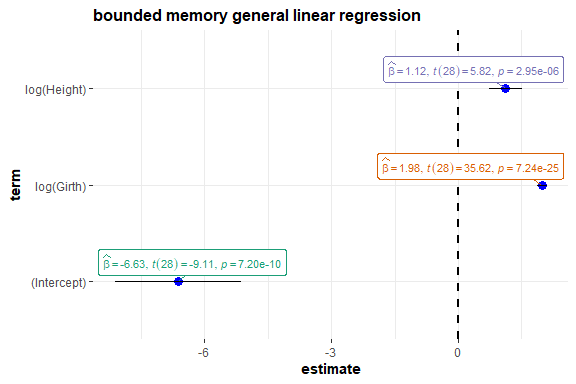

```r
# setup
set.seed(123)
library(biglm)
data(trees)

# model
mod_bigglm <-
  biglm::bigglm(
    formula = log(Volume) ~ log(Girth) + log(Height),
    data = trees,
    chunksize = 10,
    sandwich = TRUE
  )

# plot
ggcoefstats(
  x = mod_bigglm,
  title = "bounded memory general linear regression"
)
```

## efficient (general) linear model (`elm`/`eglm`)

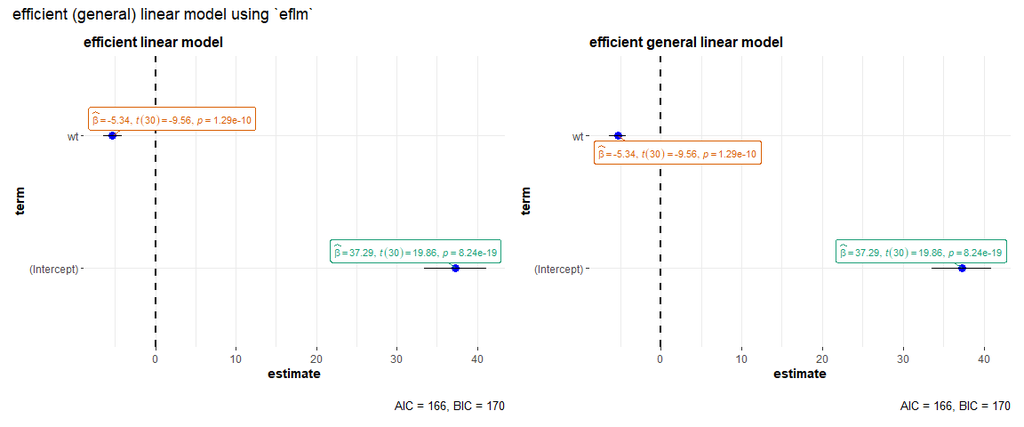

```r
# setup
set.seed(123)
library(eflm)

# models
mod_elm <- eflm::elm(mpg ~ wt, data = mtcars)
mod_eglm <- eflm::eglm(mpg ~ wt, family = gaussian(), data = mtcars)

# plot
combine_plots(
  plotlist = list(
    ggcoefstats(
      x = mod_elm,
      title = "efficient linear model"
    ),
    ggcoefstats(
      x = mod_eglm,
      title = "efficient general linear model"
    )
  ),
  plotgrid.args = list(nrow = 1),
  annotation.args = list(title = "efficient (general) linear model using `eflm`")
)
```

## nonlinear model using generalized least squares (`gnls`)

```r
set.seed(123)
library(nlme)

# variance increases with a power of the absolute fitted values
mod_gnls <- gnls(
  model = weight ~ SSlogis(Time, Asym, xmid, scal),
  data = Soybean,
  weights = varPower()
)

ggcoefstats(
  x = mod_gnls,
  title = "nonlinear model using generalized least squares"
)
```

[figure not shown]

## analysis of factorial experiments (`mixed`)

```r
# setup
set.seed(123)
library(afex)
library(MEMSS)
data("Machines", package = "MEMSS")

# simple model with random-slopes for repeated-measures factor
m1_afex <-
  afex::mixed(
    formula = score ~ Machine + (Machine | Worker),
    data = Machines
  )
```

```
#> Fitting one lmer() model. [DONE]
#> Calculating p-values. [DONE]
```

```r
# suppress correlations among random effect parameters with || and expand_re=TRUE
m2_afex <-
  afex::mixed(
    formula = score ~ Machine + (Machine || Worker),
    data = Machines,
    expand_re = TRUE
  )
```

```
#> Fitting one lmer() model. [DONE]
#> Calculating p-values. [DONE]
```

```r
# plot
combine_plots(
  plotlist = list(
    ggcoefstats(m1_afex, title = "example-1"),
    ggcoefstats(m2_afex, title = "example-2")
  ),
  annotation.args = list(title = "analysis of factorial experiments (using `afex`)")
)
```

[output not shown]

## anova using `afex` (`afex_aov`)

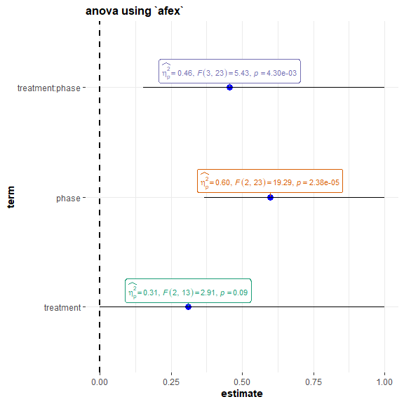

```r
# setup
set.seed(123)
library(afex)
data(obk.long)

# model
fit_all <-
  afex::aov_ez(
    "id",
    "value",
    obk.long,
    between = c("treatment"),
    within = c("phase")
  )

# plot
ggcoefstats(
  x = fit_all,
  title = "anova using `afex`"
)
```

## joint model for survival and longitudinal data measured with error (`joint`)

```r
# setup
set.seed(123)
library(joineR)

# data
data(heart.valve)
heart.surv <- UniqueVariables(heart.valve,
  var.col = c("fuyrs", "status"),
  id.col = "num"
)
heart.long <- heart.valve[, c("num", "time", "log.lvmi")]
heart.cov <- UniqueVariables(heart.valve,
  c("age", "hs", "sex"),
  id.col = "num"
)
heart.valve.jd <- jointdata(
  longitudinal = heart.long,
  baseline = heart.cov,
  survival = heart.surv,
  id.col = "num",
  time.col = "time"
)

# model
mod_joint <- joint(
  data = heart.valve.jd,
  long.formula = log.lvmi ~ 1 + time + hs,
  surv.formula = Surv(fuyrs, status) ~ hs,
  model = "intslope"
)

# plot
ggcoefstats(
  x = mod_joint,
  title = "joint model for survival and longitudinal data measured with error"
)
```

[output not shown]

## risk regression (`riskRegression`)

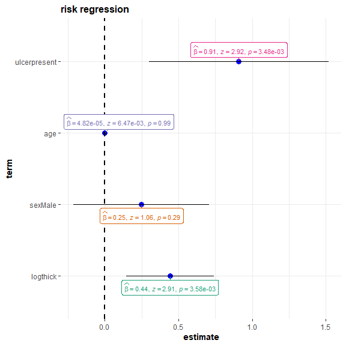

```r
# setup
set.seed(123)
library(riskRegression)
library(prodlim)
data(Melanoma, package = "riskRegression")

# tumor thickness on the log-scale
Melanoma$logthick <- log(Melanoma$thick)

# absolute risk model
multi.arr <-
  riskRegression::ARR(
    formula = Hist(time, status) ~ logthick + sex + age + ulcer,
    data = Melanoma,
    cause = 1
  )

# plot
ggcoefstats(
  x = multi.arr,
  title = "risk regression"
)
```

## Aalen’s additive regression model for censored data (`aareg`)

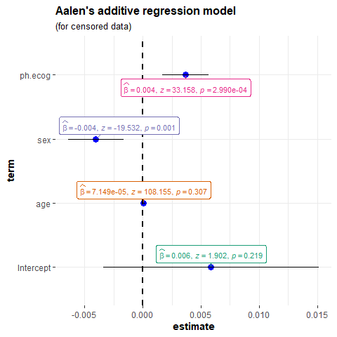

```r
# setup
library(survival)
set.seed(123)

# model
afit <-
  survival::aareg(
    formula = Surv(time, status) ~ age + sex + ph.ecog,
    data = lung,
    dfbeta = TRUE
  )

# plot
ggcoefstats(
  x = afit,
  title = "Aalen's additive regression model",
  subtitle = "(for censored data)",
  k = 3
)
```

## multivariate generalized linear mixed models (`MCMCglmm`)

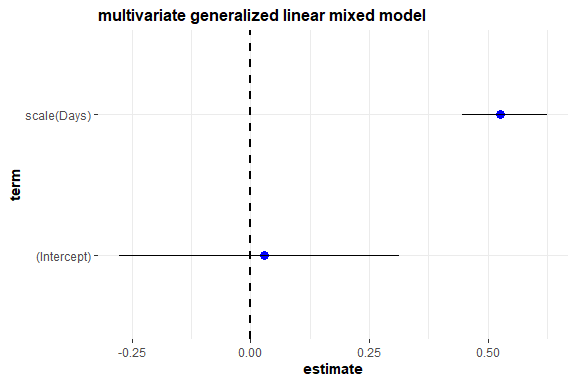

```r
# setup
set.seed(123)
library(lme4)
library(MCMCglmm)
data(sleepstudy)

# model
mm0 <-
  MCMCglmm::MCMCglmm(
    fixed = scale(Reaction) ~ scale(Days),
    random = ~Subject,
    data = lme4::sleepstudy,
    nitt = 4000,
    pr = TRUE,
    verbose = FALSE
  )

# plot
ggcoefstats(
  x = mm0,
  title = "multivariate generalized linear mixed model",
  conf.method = "HPDinterval",
  robust = TRUE # additional arguments passed to `parameters::model_parameters`
)
```

## STAR Models with BayesX (`bayesx`)

```r
# setup
set.seed(111)
library(R2BayesX)
```

[output not shown]

```r
## generate some data
n <- 200

## regressor
dat <- data.frame(x = runif(n, -3, 3))

## response
dat$y <- with(dat, 1.5 + sin(x) + rnorm(n, sd = 0.6))

## estimate models with bayesx REML and MCMC
b1 <- R2BayesX::bayesx(y ~ sx(x), method = "REML", data = dat)
```

[output not shown]

```r
# plot
ggcoefstats(
  x = b1,
  title = "STAR Models with BayesX"
)
```

[output not shown]

## Generalised Joint Regression Models with Binary/Continuous/Discrete/Survival Margins (`gjrm`)

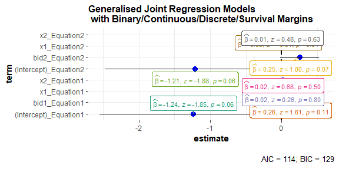

```r
library(GJRM)

# data
set.seed(123)
dat <- data.frame(
  x1 = rnorm(40, 1:10),
  x2 = rnorm(40, 1:30),
  bid1 = sample(1:5, 40, replace = TRUE),
  bid2 = sample(1:5, 40, replace = TRUE),
  y1 = sample(0:1, 40, replace = TRUE),
  y2 = sample(0:1, 40, replace = TRUE)
)

f.list <- list(
  y1 ~ bid1 + x1 + x2,
  y2 ~ bid2 + x1 + x2
)

# model
mod_gjrm <- gjrm(f.list, dat, Model = "B", margins = c("probit", "probit"))

# plot
ggcoefstats(
  x = mod_gjrm,
  title = "Generalised Joint Regression Models\n with Binary/Continuous/Discrete/Survival Margins"
)
```

## Heckman-style selection and treatment effect models (`selection`)

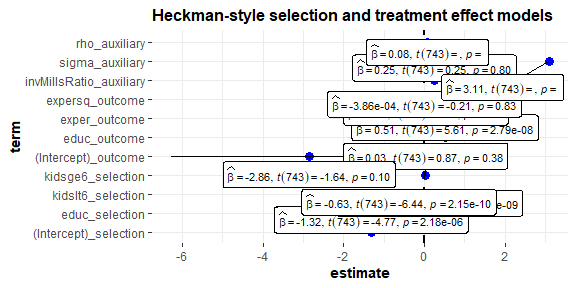

```r
library(sampleSelection)
library(wooldridge) # for data
data(mroz)

# model
mod_selection <- selection(
  inlf ~ educ + kidslt6 + kidsge6,
  wage ~ educ + exper + expersq,
  method = "2step",
  data = mroz
)

# plot
ggcoefstats(
  x = mod_selection,
  title = "Heckman-style selection and treatment effect models"
)
```

## inference in spatial GLMMs (`HLfit`)

```r
# setup
set.seed(123)
library(spaMM)
data("wafers")
data("scotlip")

# model
mod_HLfit <-
  fitme(
    formula = y ~ 1 + (1 | batch),
    family = Gamma(log),
    data = wafers
  )

# plot
ggcoefstats(
  x = mod_HLfit,
  title = "Inference in spatial GLMMs"
)
```

[output not shown]

## robust linear mixed-effects models (`rlmer`)

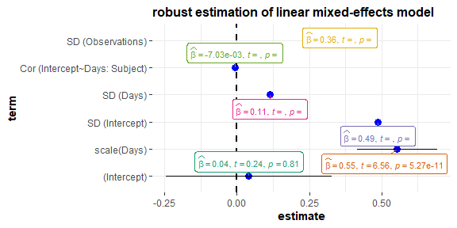

```r
# setups
set.seed(123)
library(robustlmm)

# model
roblmm.mod <-
  robustlmm::rlmer(
    formula = scale(Reaction) ~ scale(Days) + (Days | Subject),
    data = sleepstudy,
    rho.sigma.e = psi2propII(smoothPsi, k = 2.28),
    rho.sigma.b = chgDefaults(smoothPsi, k = 5.11, s = 10)
  )

# plot
ggcoefstats(
  x = roblmm.mod,
  title = "robust estimation of linear mixed-effects model",
  conf.level = 0.90
)
```

## linear mixed-effects models with `lmerTest` (`lmerModLmerTest`)

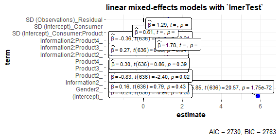

```r
# setup
set.seed(123)
library(lmerTest)

# fit linear mixed model to the ham data:
fm <-
  lmerTest::lmer(
    formula = Informed.liking ~ Gender + Information * Product + (1 | Consumer) +
      (1 | Consumer:Product),
    data = ham
  )

# plot
ggcoefstats(
  x = fm,
  title = "linear mixed-effects models with `lmerTest`"
)
```

## non-linear mixed-effects model (`nlmer`/`nlmerMod`)

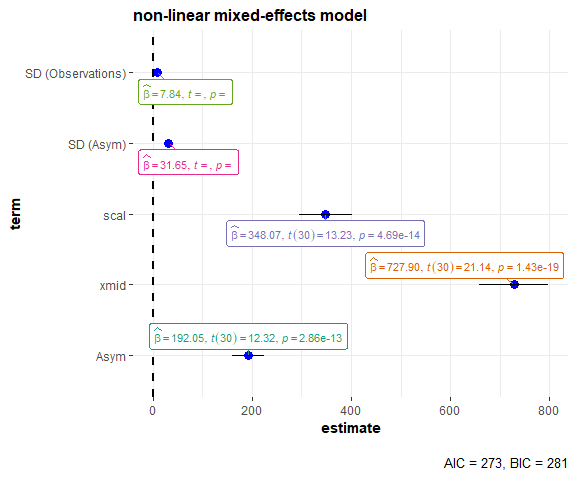

```r
# data
library(lme4)
set.seed(123)
startvec <- c(Asym = 200, xmid = 725, scal = 350)

# model
nm1 <-
  lme4::nlmer(
    formula = circumference ~ SSlogis(age, Asym, xmid, scal) ~ Asym | Tree,
    data = Orange,
    start = startvec
  )

# plot
ggcoefstats(
  x = nm1,
  title = "non-linear mixed-effects model"
)
```

## non-linear least-squares model (`nls`)

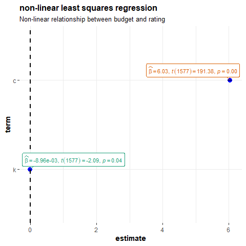

```r
# setup
set.seed(123)
library(ggstatsplot)

# model
mod_nls <-
  stats::nls(
    formula = rating ~ k / budget + c,
    data = movies_long,
    start = list(k = 1, c = 0)
  )

# plot
ggcoefstats(
  x = mod_nls,
  title = "non-linear least squares regression",
  subtitle = "Non-linear relationship between budget and rating"
)
```

## conditional generalized linear models for clustered data (`cglm`)

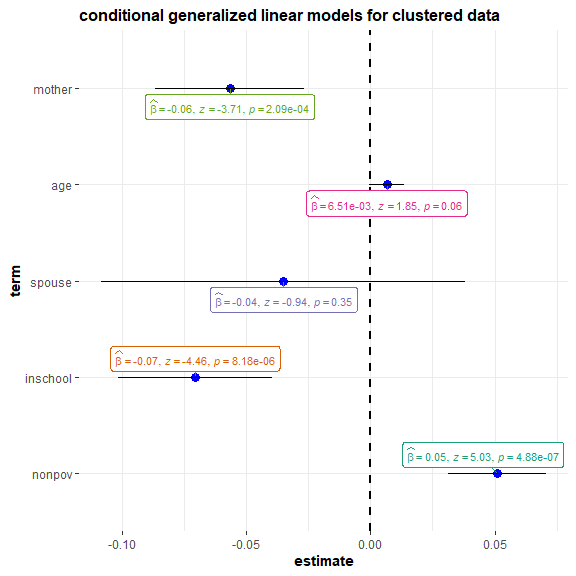

```r
# setup
set.seed(123)
library(cglm)
data(teenpov)

# model
fit.ide <-
  cglm::cglm(
    method = "ts",
    formula = hours ~ nonpov + inschool + spouse + age + mother,
    data = teenpov,
    id = "ID",
    link = "identity"
  )

# plot
ggcoefstats(
  x = fit.ide,
  title = "conditional generalized linear models for clustered data"
)
```

## joint model to time-to-event data and multivariate longitudinal data (`mjoint`)

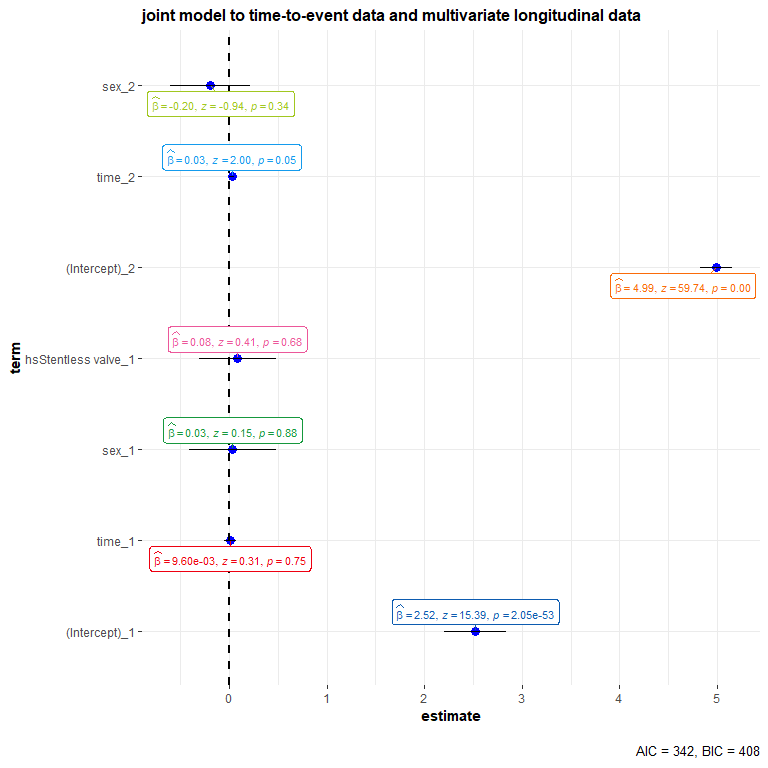

```r
# setup
set.seed(123)
library(joineRML)
data(heart.valve)

# data
hvd <- heart.valve[!is.na(heart.valve$log.grad) &
  !is.na(heart.valve$log.lvmi) &
  heart.valve$num <= 50, ]

# model
fit_mjoint <- joineRML::mjoint(
  formLongFixed = list(
    "grad" = log.grad ~ time + sex + hs,
    "lvmi" = log.lvmi ~ time + sex
  ),
  formLongRandom = list(
    "grad" = ~ 1 | num,
    "lvmi" = ~ time | num
  ),
  formSurv = Surv(fuyrs, status) ~ age,
  data = hvd,
  inits = list("gamma" = c(0.11, 1.51, 0.80)),
  timeVar = "time"
)

# extract the survival fixed effects and plot them
ggcoefstats(
  x = fit_mjoint,
  component = "conditional",
  package = "yarrr",
  palette = "basel",
  title = "joint model to time-to-event data and multivariate longitudinal data"
)
```

## stationary linear model (`slm`)

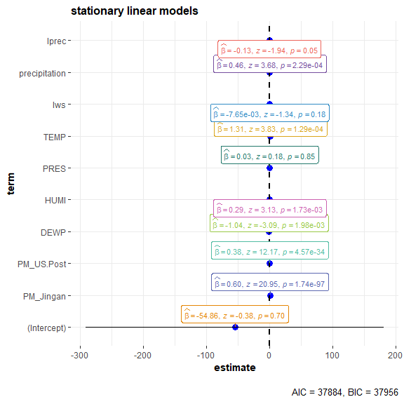

```r
# setup
set.seed(123)
library(slm)
data("shan")

# model
mod_slm <-
  slm::slm(
    myformula = shan$PM_Xuhui ~ .,
    data = shan,
    method_cov_st = "fitAR",
    model_selec = -1
  )

# plot
ggcoefstats(
  x = mod_slm,
  conf.level = 0.90,
  title = "stationary linear models",
  package = "rcartocolor",
  palette = "Vivid"
)
```